# Identifying effective climate policies in Austria: a reverse-causal analysis

April 2023

## Overview

**Motivation**

- *Personally*: renewable energy sector; environmental science; interest in climate policy
- *A Climate Plan for Austria*: specific focus on Austria for the project
- *Testing methodology*: application of methodology to sectors other than road transport emissions

**Methodology**

- Replication of Koch et al. (2022)
- Reverse causal approach using GETS, for all Austrian sectors
- Samples: EU15 and EU31
- Target significance levels: 5%, 1% and 0.1%

**Data**

- IEA-EDGAR CO2 emissions database (v7.0)
- 1996-2021
- Updated from EDGAR v5.0 from the original paper (1996-2018)

## Overview

**Emissions breakdown in Austria**

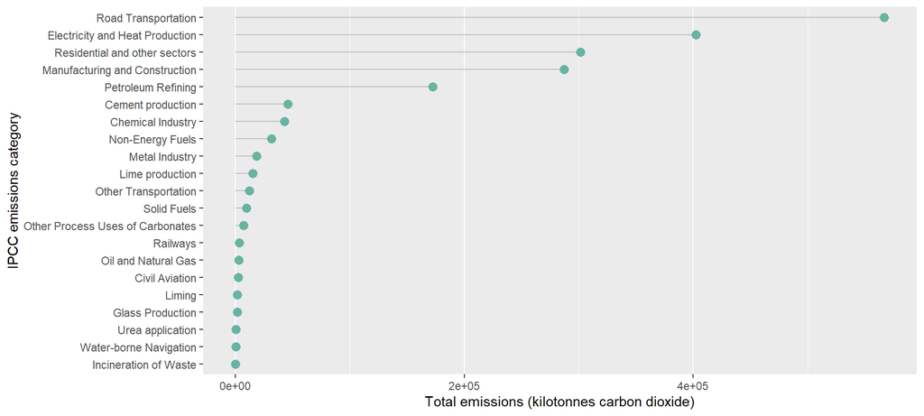

Emissions by sector in Austria

## Key Results

**Negative structural breaks in Austrian emissions**

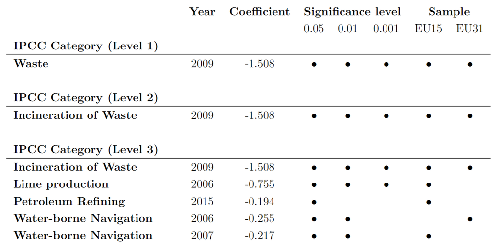

## Key Results

**Log of emissions per capita for Austrian sectors and counterfactuals**

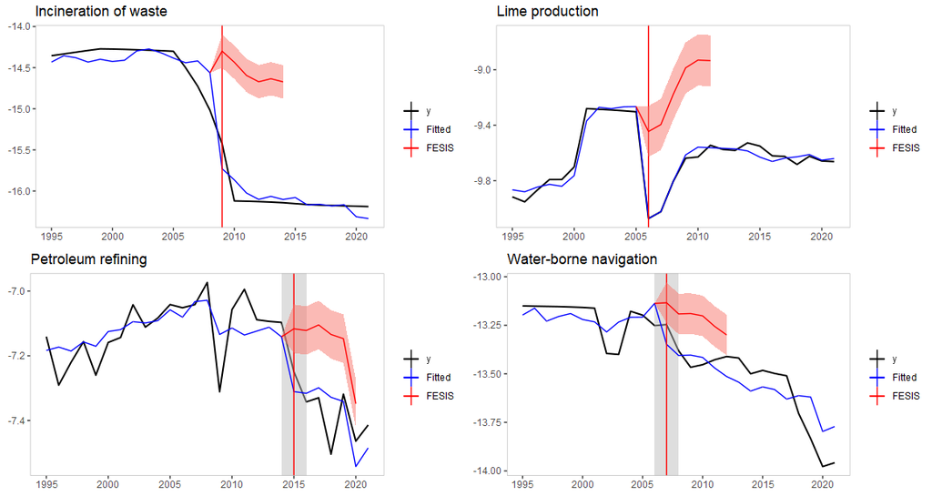

## Key Results

**Policy attribution to identified structural breaks**

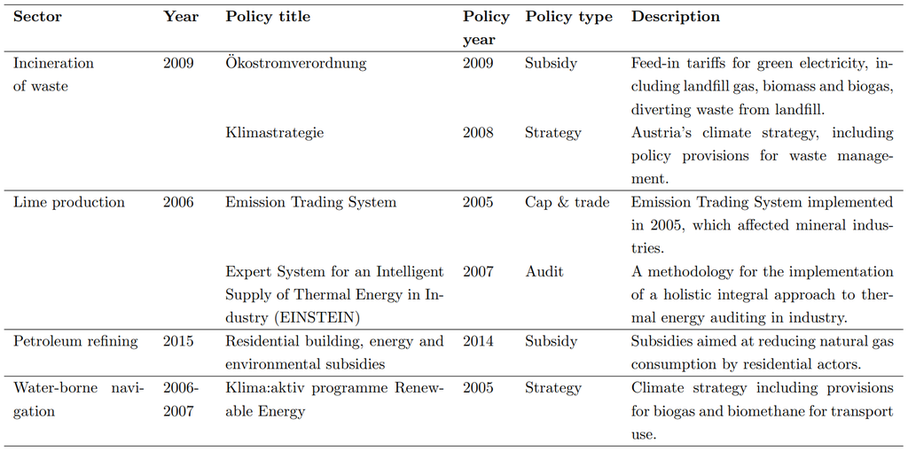

## Challenges and Future Opportunities

**Challenges**

- Calculating confidence intervals (currently reviewing Hendry and Pretis, 2023)
- Slightly different results using EDGAR v5.0 compared to EDGAR v7.0 combined database
- Approach to identifying EU-wide policies
- Causal interpretation

**Future Work**

- *Role models*: look for most effective policies across Europe and highlight role model countries and policies. Focus on largest sectors
- *Upward breaks*: investigate the causes of upward breaks
- *Demand vs. supply*: Investigate the effectiveness of demand- vs. supply-side policies across Europe

**Questions**

- Why a focus on road emissions? (More straightforward policy attribution? Relative volume of emissions?)